# Ford GoBike System Data

## Preliminary Wrangling

> This data set includes information about individual rides made in a bike-sharing system covering the greater San Francisco Bay area.

```python
# import all packages and set plots to be embedded inline
import numpy as np
import pandas as pd
import matplotlib.pyplot as plt
import seaborn as sb
import os
import datetime

%matplotlib inline
```

```python
#laod data from a .csv file
df = pd.read_csv('../2017-fordgobike-tripdata.csv')
df.sample(10)
```

|  | duration_sec | start_time | end_time | start_station_id | start_station_name | start_station_latitude | start_station_longitude | end_station_id | end_station_name | end_station_latitude | end_station_longitude | bike_id | user_type | member_birth_year | member_gender |
| --- | --- | --- | --- | --- | --- | --- | --- | --- | --- | --- | --- | --- | --- | --- | --- |
| 462155 | 772 | 2017-08-05 14:34:14.6330 | 2017-08-05 14:47:06.9280 | 137 | Jersey St at Castro St | 37.750506 | -122.433950 | 137 | Jersey St at Castro St | 37.750506 | -122.433950 | 2658 | Subscriber | 1963.0 | Male |
| 494166 | 1328 | 2017-07-20 11:41:43.4820 | 2017-07-20 12:03:52.2340 | 16 | Steuart St at Market St | 37.794130 | -122.394430 | 6 | The Embarcadero at Sansome St | 37.804770 | -122.403234 | 119 | Customer | NaN | NaN |
| 250876 | 1606 | 2017-10-12 08:54:51.4580 | 2017-10-12 09:21:38.0050 | 35 | Cahill Park | 37.329119 | -121.904576 | 300 | Palm St at Willow St | 37.317298 | -121.884995 | 812 | Subscriber | 1986.0 | Male |
| 377207 | 729 | 2017-09-05 19:53:42.1520 | 2017-09-05 20:05:52.0170 | 61 | Howard St at 8th St | 37.776513 | -122.411306 | 43 | San Francisco Public Library (Grove St at Hyde... | 37.778768 | -122.415929 | 1676 | Subscriber | 1981.0 | Male |
| 59472 | 548 | 2017-12-08 13:00:35.0960 | 2017-12-08 13:09:43.8890 | 74 | Laguna St at Hayes St | 37.776435 | -122.426244 | 84 | Duboce Park | 37.769201 | -122.433812 | 589 | Subscriber | 1969.0 | Male |
| 301849 | 508 | 2017-09-27 19:20:07.6210 | 2017-09-27 19:28:35.7370 | 201 | 10th St at Fallon St | 37.797673 | -122.262997 | 200 | 2nd Ave at E 18th St | 37.800214 | -122.253810 | 1199 | Subscriber | 1954.0 | Male |
| 128021 | 193 | 2017-11-16 16:03:49.1200 | 2017-11-16 16:07:02.4210 | 17 | Embarcadero BART Station (Beale St at Market St) | 37.792251 | -122.397086 | 27 | Beale St at Harrison St | 37.788059 | -122.391865 | 2725 | Subscriber | 1979.0 | Male |
| 249704 | 501 | 2017-10-12 16:22:42.6430 | 2017-10-12 16:31:04.2500 | 30 | San Francisco Caltrain (Townsend St at 4th St) | 37.776598 | -122.395282 | 24 | Spear St at Folsom St | 37.789677 | -122.390428 | 519 | Subscriber | 1985.0 | Male |
| 451219 | 515 | 2017-08-10 08:26:24.8140 | 2017-08-10 08:35:00.0540 | 30 | San Francisco Caltrain (Townsend St at 4th St) | 37.776598 | -122.395282 | 25 | Howard St at 2nd St | 37.787522 | -122.397405 | 2509 | Subscriber | 1987.0 | Female |
| 74653 | 476 | 2017-12-04 20:02:20.5030 | 2017-12-04 20:10:17.0650 | 129 | Harrison St at 20th St | 37.758862 | -122.412544 | 114 | Rhode Island St at 17th St | 37.764478 | -122.402570 | 676 | Subscriber | 1995.0 | Male |

```python
#get informationa about dataset
df.info()
```

```
<class 'pandas.core.frame.DataFrame'>
RangeIndex: 519700 entries, 0 to 519699
Data columns (total 15 columns):
duration_sec               519700 non-null int64
start_time                 519700 non-null object
end_time                   519700 non-null object
start_station_id           519700 non-null int64
start_station_name         519700 non-null object
start_station_latitude     519700 non-null float64
start_station_longitude    519700 non-null float64
end_station_id             519700 non-null int64
end_station_name           519700 non-null object
end_station_latitude       519700 non-null float64
end_station_longitude      519700 non-null float64
bike_id                    519700 non-null int64
user_type                  519700 non-null object
member_birth_year          453159 non-null float64
member_gender              453238 non-null object
dtypes: float64(5), int64(4), object(6)
memory usage: 59.5+ MB
```

**Note:** member_birth_year and member_gender variables have missing data

```python
df.describe()
```

|  | duration_sec | start_station_id | start_station_latitude | start_station_longitude | end_station_id | end_station_latitude | end_station_longitude | bike_id | member_birth_year |
| --- | --- | --- | --- | --- | --- | --- | --- | --- | --- |
| count | 519700.000000 | 519700.000000 | 519700.000000 | 519700.000000 | 519700.000000 | 519700.000000 | 519700.000000 | 519700.000000 | 453159.000000 |
| mean | 1099.009521 | 95.034245 | 37.771653 | -122.363927 | 92.184041 | 37.771844 | -122.363236 | 1672.533079 | 1980.404787 |
| std | 3444.146451 | 86.083078 | 0.086305 | 0.105573 | 84.969491 | 0.086224 | 0.105122 | 971.356959 | 10.513488 |
| min | 61.000000 | 3.000000 | 37.317298 | -122.444293 | 3.000000 | 37.317298 | -122.444293 | 10.000000 | 1886.000000 |
| 25% | 382.000000 | 24.000000 | 37.773492 | -122.411726 | 23.000000 | 37.774520 | -122.410345 | 787.000000 | 1974.000000 |
| 50% | 596.000000 | 67.000000 | 37.783521 | -122.398870 | 66.000000 | 37.783830 | -122.398525 | 1728.500000 | 1983.000000 |
| 75% | 938.000000 | 139.000000 | 37.795392 | -122.391034 | 134.000000 | 37.795392 | -122.391034 | 2520.000000 | 1988.000000 |
| max | 86369.000000 | 340.000000 | 37.880222 | -121.874119 | 340.000000 | 37.880222 | -121.874119 | 3733.000000 | 1999.000000 |

```python
#perform some data cleaning
df = df.dropna() #drop rows with missing values
#drop unused cloumns
df = df.drop(['start_station_latitude','start_station_longitude','end_station_latitude','end_station_longitude',
              'bike_id', 'start_station_id', 'end_station_id', 'user_type' ], axis=1)
#make member_birth_year int
df.member_birth_year=df.member_birth_year.astype('int64')
df.start_time = pd.to_datetime(df.start_time) #string to datatime
df.end_time = pd.to_datetime(df.end_time) #string to datatime
```

```python
df['age'] = pd.DatetimeIndex(df['start_time']).year - df.member_birth_year #find age of the user
df['hour'] = pd.DatetimeIndex(df['start_time']).hour #hour of a day when bike is taken
df['dow'] = df.start_time.dt.dayofweek+1 #extract day of a week and "+1" makes Monday - 1, not 0
df.loc[df.hour == 0, 'hour'] = 24 #to avoid log(0) make 0 -> 24
df['duration_min'] = (df.duration_sec / 60).astype('int64') #add column - duration in minutes
df=df.query('member_gender != "Other"') #consider Other as outlier
df.sample(10)
```

|  | duration_sec | start_time | end_time | start_station_name | end_station_name | member_birth_year | member_gender | age | hour | dow | duration_min |
| --- | --- | --- | --- | --- | --- | --- | --- | --- | --- | --- | --- |
| 157959 | 726 | 2017-11-07 18:13:53.501 | 2017-11-07 18:25:59.580 | 7th St at Brannan St | Garfield Square (25th St at Harrison St) | 1986 | Male | 31 | 18 | 2 | 12 |
| 378548 | 646 | 2017-09-05 16:16:32.184 | 2017-09-05 16:27:18.991 | Civic Center/UN Plaza BART Station (Market St ... | San Francisco Caltrain Station 2 (Townsend St... | 1987 | Male | 30 | 16 | 2 | 10 |
| 147498 | 98 | 2017-11-10 11:29:33.132 | 2017-11-10 11:31:11.566 | Webster St at Grove St | Webster St at Grove St | 1986 | Female | 31 | 11 | 5 | 1 |
| 20861 | 458 | 2017-12-19 22:36:52.886 | 2017-12-19 22:44:31.132 | San Fernando St at 4th St | Ryland Park | 1994 | Male | 23 | 22 | 2 | 7 |
| 65542 | 402 | 2017-12-07 06:27:34.066 | 2017-12-07 06:34:16.178 | 24th St at Chattanooga St | Valencia St at 24th St | 1967 | Male | 50 | 6 | 4 | 6 |
| 29798 | 1261 | 2017-12-17 12:26:21.532 | 2017-12-17 12:47:22.602 | William St at 10th St | William St at 10th St | 1996 | Male | 21 | 12 | 7 | 21 |
| 476532 | 791 | 2017-07-29 19:27:00.123 | 2017-07-29 19:40:12.031 | The Embarcadero at Sansome St | 5th St at Howard St | 1981 | Female | 36 | 19 | 6 | 13 |
| 515585 | 284 | 2017-07-03 17:09:04.377 | 2017-07-03 17:13:48.512 | 5th St at Howard St | Powell St BART Station (Market St at 4th St) | 1981 | Male | 36 | 17 | 1 | 4 |
| 247288 | 261 | 2017-10-13 09:35:12.073 | 2017-10-13 09:39:33.784 | Mechanics Monument Plaza (Market St at Bush St) | Commercial St at Montgomery St | 1984 | Male | 33 | 9 | 5 | 4 |
| 217601 | 269 | 2017-10-22 14:33:48.455 | 2017-10-22 14:38:17.993 | Garfield Square (25th St at Harrison St) | Harrison St at 20th St | 1988 | Female | 29 | 14 | 7 | 4 |

```python
df.drop(['duration_sec', 'member_birth_year', 'start_time', 'end_time'], axis = 1, inplace=True)
print(df.info())
df.head()
```

```
<class 'pandas.core.frame.DataFrame'>
Int64Index: 446860 entries, 0 to 519699
Data columns (total 7 columns):
start_station_name    446860 non-null object
end_station_name      446860 non-null object
member_gender         446860 non-null object
age                   446860 non-null int64
hour                  446860 non-null int64
dow                   446860 non-null int64
duration_min          446860 non-null int64
dtypes: int64(4), object(3)
memory usage: 27.3+ MB
None
```

|  | start_station_name | end_station_name | member_gender | age | hour | dow | duration_min |
| --- | --- | --- | --- | --- | --- | --- | --- |
| 0 | Laguna St at Hayes St | San Francisco Public Library (Grove St at Hyde... | Male | 30 | 16 | 7 | 1335 |
| 1 | Yerba Buena Center for the Arts (Howard St at ... | Dolores St at 15th St | Female | 52 | 15 | 7 | 1313 |
| 4 | Bancroft Way at Telegraph Ave | Fulton St at Bancroft Way | Female | 20 | 14 | 7 | 726 |
| 6 | Addison St at Fourth St | Addison St at Fourth St | Female | 26 | 23 | 7 | 75 |
| 12 | San Francisco Caltrain Station 2 (Townsend St... | Spear St at Folsom St | Male | 27 | 23 | 7 | 36 |

### What is/are the main feature(s) of interest in your dataset?

> The main features of interests are duration, hour and days of the week when bikes are usually taken for a ride.

### What features in the dataset do you think will help support your investigation into your feature(s) of interest?

> Member_gender, age, hour, we will also define routes between start_station_name and end_station_name

## Univariate Exploration

First, let us plot a histogram of duraion and find when bikes are more likely to be taken

```python
np.log10(df.duration_min).describe() #we will use log scale, so take a look at the log transform values .describe
```

```
count    446860.000000
mean          0.941256
std           0.325042
min           0.000000
25%           0.778151
50%           0.954243
75%           1.113943
max           3.157457
Name: duration_min, dtype: float64
```

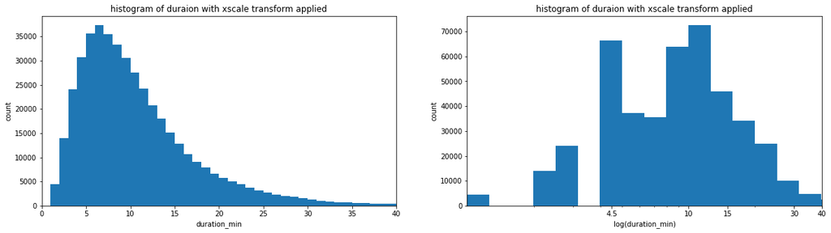

```python
plt.figure(figsize = [20,5])
#plot the hist on natural scale
plt.subplot(1,2,1)
plt.xlim(0,100)
bin_edges = np.arange(0, df.duration_min.max()+5, 1)
sb.distplot(df.duration_min, kde=False, hist_kws ={'alpha':1}, bins = bin_edges);
plt.xlim(0,40)
plt.title('histogram of duraion with xscale transform applied')
plt.ylabel('count');

#plot the hist in log scale
plt.subplot(1,2,2)
bin_edges = 10 ** np.arange(0, np.log10(df.duration_min.max()+0.1), 0.1)
sb.distplot(df.duration_min, kde=False, hist_kws ={'alpha':1} , bins = bin_edges);
plt.xscale('log');
tick_locs = [4.5,10, 15, 30, 40];
plt.xticks(tick_locs, tick_locs);
plt.xlabel('log(duration_min)');
plt.xlim(1, 40);
plt.title('histogram of duraion with xscale transform applied')
plt.ylabel('count');
```

**Comments** When we plot the hist on the real values we can see that the histogram is right skewed with the mode about 7 min. After plotting the histogram on log transformed x-axis we can see two modes: 4 min and about 11 min.

Plot a hour histogram to find the time of the day when bikes are more likely to be taken for ride

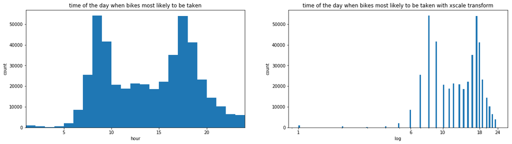

```python
plt.figure(figsize = [20,5])

plt.subplot(1,2,1)
plt.xlim(1,24)
bin_edges = np.arange(0, df.hour.max()+1, 1)
sb.distplot(df.hour, kde=False, hist_kws ={'alpha':1}, bins = bin_edges);
plt.ylabel('count');
plt.title('time of the day when bikes most likely to be taken')

plt.subplot(1,2,2)
bin_edges = 10 ** np.arange(0, np.log10(df.hour.max()+0.1), 0.01)
sb.distplot(df.hour, kde=False, hist_kws ={'alpha':1} , bins = bin_edges);
plt.xscale('log');
tick_locs = [1,6, 10, 18, 24];
plt.xticks(tick_locs, tick_locs);
plt.xlabel('log(duration_min)');
plt.xlabel('log');
plt.ylabel('count');
plt.title('time of the day when bikes most likely to be taken with xscale transform');
```

**Comments** We can see that this histogram plotted on real values has two modes at 8 and 17. It is confirmed on a log scale plot. We can see that the time when bikes are most likely are taken is 8 am, when people going to work and at 18 when people are coming from work.

Plot a day of the week barchart showing the number of times bikes are taken each day of the week

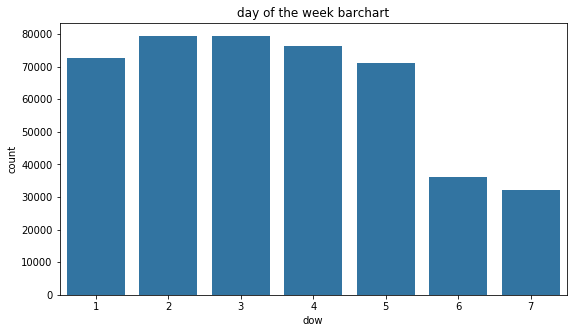

```python
base_color = sb.color_palette()[0]

plt.figure(figsize = [20,5])

plt.subplot(1,2,1)
sb.countplot(df.dow, color=base_color);
plt.title('day of the week barchart');
```

**Comments** We can see that during weekdays the dustibution is almost uniform with the the number of total rides between 71000 and less than 80000. On weekends bikes are taken less than on weekdays and the number of total rides is about 35000

Let's take a look at age and gender distributions

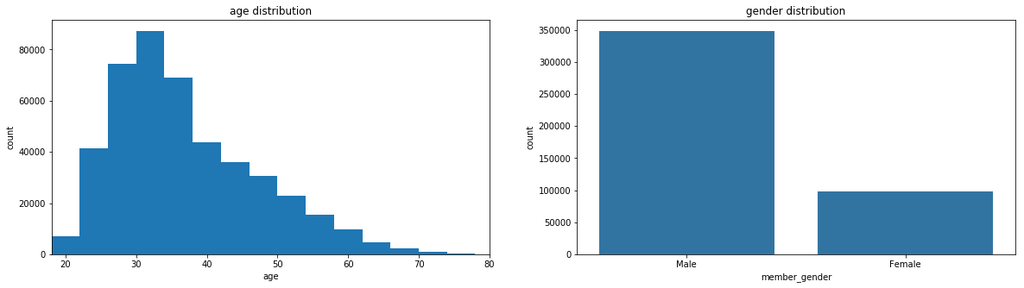

```python
plt.figure(figsize = [20,5])

plt.subplot(1,2,1)
width = 4
bin_edges = np.arange(df.age.min(),  df.age.max()+width, width);
sb.distplot(df.age, kde=False, hist_kws ={'alpha':1}, bins = bin_edges);
plt.xlim(df.age.min(), 80); #there are some outliers: some of them above 80 and others close to 120, I believe it is possible but can be a mistake
plt.ylabel('count');
plt.title('age distribution');

plt.subplot(1,2,2);
sb.countplot(df.member_gender, color = base_color);
plt.ylabel('count');
plt.title('gender distribution');
```

Find 4 most popular starting stations and correspong 4 most popular arrival stations. Plot the bar chart for these routes.

```python
#find 4 most popular starting station
idx1 = df.start_station_name.value_counts().index[0:4]
df_often = df.loc[df['start_station_name'].isin(idx1)]
#find 4 most popular arriving stations in the df_often dataset
idx2=df_often.end_station_name.value_counts().index[0:4]
df_often=df.loc[df['end_station_name'].isin(idx2)]
k = 1
df_often['route'] = 0
mapping_list = []
#number each route, total 16
for i in idx1:
    for j in idx2:
        df_often.loc[(df_often['start_station_name']==i) & (df_often['end_station_name']==j), 'route'] = k
        mapping_list.append({'route' : k,
                       'start_station_name': i,
                      'end_station_name' : j})
        k+=1

#map # of routes with corresponding stations
mapping_df = pd.DataFrame(mapping_list, columns = ['route', 'start_station_name', 'end_station_name'])
df_often = df_often.query('route != 0') #remove values which don't correspond to any routes between stations
df_often.route= df_often.route.astype('category')
```

Below is a mapping between routes and start_station_name - end_station_name

```python
mapping_df
```

|  | route | start_station_name | end_station_name |
| --- | --- | --- | --- |
| 0 | 1 | San Francisco Caltrain (Townsend St at 4th St) | The Embarcadero at Sansome St |
| 1 | 2 | San Francisco Caltrain (Townsend St at 4th St) | Montgomery St BART Station (Market St at 2nd St) |
| 2 | 3 | San Francisco Caltrain (Townsend St at 4th St) | Howard St at 2nd St |
| 3 | 4 | San Francisco Caltrain (Townsend St at 4th St) | San Francisco Ferry Building (Harry Bridges Pl... |
| 4 | 5 | San Francisco Caltrain Station 2 (Townsend St... | The Embarcadero at Sansome St |
| 5 | 6 | San Francisco Caltrain Station 2 (Townsend St... | Montgomery St BART Station (Market St at 2nd St) |
| 6 | 7 | San Francisco Caltrain Station 2 (Townsend St... | Howard St at 2nd St |
| 7 | 8 | San Francisco Caltrain Station 2 (Townsend St... | San Francisco Ferry Building (Harry Bridges Pl... |
| 8 | 9 | San Francisco Ferry Building (Harry Bridges Pl... | The Embarcadero at Sansome St |
| 9 | 10 | San Francisco Ferry Building (Harry Bridges Pl... | Montgomery St BART Station (Market St at 2nd St) |
| 10 | 11 | San Francisco Ferry Building (Harry Bridges Pl... | Howard St at 2nd St |
| 11 | 12 | San Francisco Ferry Building (Harry Bridges Pl... | San Francisco Ferry Building (Harry Bridges Pl... |
| 12 | 13 | Market St at 10th St | The Embarcadero at Sansome St |
| 13 | 14 | Market St at 10th St | Montgomery St BART Station (Market St at 2nd St) |
| 14 | 15 | Market St at 10th St | Howard St at 2nd St |
| 15 | 16 | Market St at 10th St | San Francisco Ferry Building (Harry Bridges Pl... |

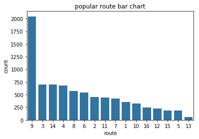

```python
cat_order = df_often.route.value_counts().index;
sb.countplot(df_often.route, color = base_color, order = cat_order);
plt.title('popular route bar chart');
```

### Of the features you investigated, were there any unusual distributions? Did you perform any operations on the data to tidy, adjust, or change the form of the data? If so, why did you do this?

> Some data cleaning and preparation were completed such as removing unnecessary variable, change the data types. New variables were introduce to our dataset such as hour, age and route.

## Bivariate Exploration

Construct FacetGrid for the distribution for the log duration as it is shown on the first plot but splitted by days of the week.

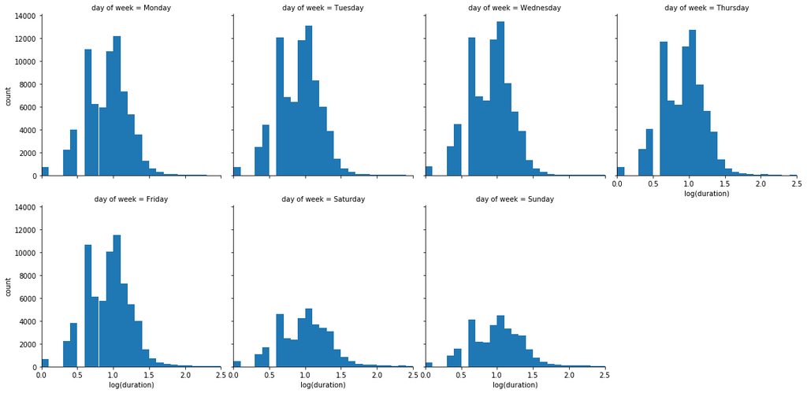

```python
#Let's define categorical variable for dow
df["day of week"] = np.nan
df.loc[df.dow == 1, "day of week" ] = "Monday"
df.loc[df.dow == 2, "day of week" ] = "Tuesday"
df.loc[df.dow == 3, "day of week" ] = "Wednesday"
df.loc[df.dow == 4, "day of week" ] = "Thursday"
df.loc[df.dow == 5, "day of week" ] = "Friday"
df.loc[df.dow == 6, "day of week" ] = "Saturday"
df.loc[df.dow == 7, "day of week" ] = "Sunday"
ordinal_var_dict = {"day of week": ['Monday','Tuesday','Wednesday','Thursday','Friday', "Saturday", "Sunday"]}
ordered_var = pd.api.types.CategoricalDtype(ordered = True, categories = ordinal_var_dict["day of week"] )
df["day of week"] = df["day of week"].astype(ordered_var)

df.sample(10)
df['log_duration'] = np.log10(df.duration_min)
bin_edges = bin_edges = np.arange(0, np.log10(df.duration_min.max()+0.1), 0.1)
g = sb.FacetGrid(data=df, col = 'day of week',  margin_titles = True, col_wrap= 4 , height =4);
g.map(sb.distplot, 'log_duration', kde=False, bins = bin_edges, hist_kws ={'alpha':1}).set(xlim=(0,2.5));
g.set_xlabels("log(duration)");
g.set_ylabels('count')
```

It is interesting that for all days of the week the distribution mimics the first distribution from the univariant part of the project. However, on weekends, distributions have similar shapes compare to weekdays but the number of bike usage is significantly lower.

Plot relationship between hour of the day and day of the week

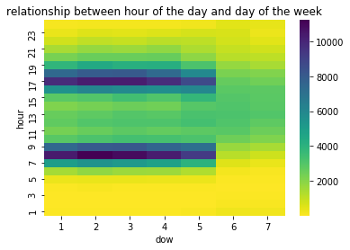

```python
#let's prepare data for heatmap
ct_counts = df.groupby(['hour', 'dow']).size()
ct_counts = ct_counts.reset_index(name = 'count')
ct_counts =ct_counts.pivot(index = 'hour', columns = 'dow', values = 'count')
ct_counts.fillna(0, inplace=True)
ax = sb.heatmap(ct_counts, cmap = 'viridis_r');
ax.invert_yaxis();
plt.title('relationship between hour of the day and day of the week');
```

Plot average duration with respect to the day of a week

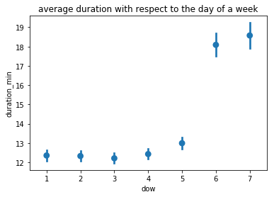

```python
sb.pointplot(data=df, x='dow',y="duration_min", linestyles="");
plt.title("average duration with respect to the day of a week");
```

**Comment** We can see that during the weekdays the average time of bike usage is between 12 and 13 min; however, on weekends it is between 18 and 19 minuts.

Plot the heatmap between age and gender.

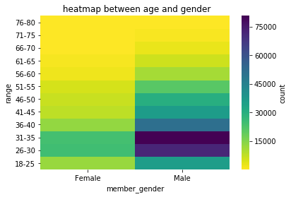

```python
ct_counts =df.query('age < 80')
ct_counts['range'] = pd.cut(ct_counts.age, [18, 25, 30, 35, 40, 45, 50, 55, 60, 65, 70, 75, 80], include_lowest=True,
                           labels = ['18-25', '26-30', '31-35', '36-40', '41-45', '46-50', '51-55', '56-60', '61-65', '66-70',
                                    '71-75', '76-80'])
ct_counts = ct_counts.groupby(['range', 'member_gender']).size()
ct_counts = ct_counts.reset_index(name = 'count')
ct_counts = ct_counts.pivot(index = 'range', columns = 'member_gender', values = 'count')
ax= sb.heatmap(ct_counts, cmap = 'viridis_r', cbar_kws = {'label' : 'count'},)
ax.invert_yaxis();
plt.title(" heatmap between age and gender");
```

**Comment** We can see that men between 31-35 use bikes most often, men between 26-30 years use bike a litle bit less. Women between 26-35 use bikes most often but about 2.5 times less than men at the age 31-35. The number of rides gradually decrease for men and women when they reach 76-80 years old.

Plot violinplot of duration with respect to route.

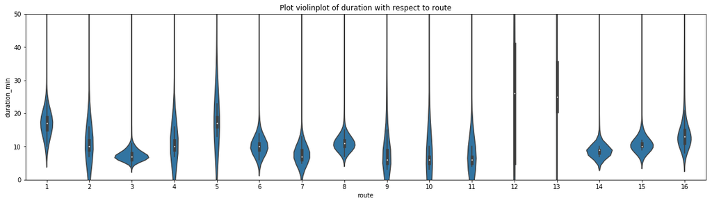

```python
plt.figure(figsize = [20,5])
sb.violinplot(data = df_often, x = df_often.route, y = df_often.duration_min, color = base_color )
plt.ylim(0,50)
plt.title("Plot violinplot of duration with respect to route");
```

## Multivariate Exploration

Plot the clustered bar chart of the average duration with respect to weekdays for each gender.

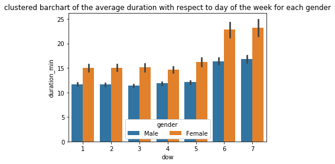

```python
ax = sb.barplot(data = df, x = 'dow', y = 'duration_min', hue = 'member_gender');
ax.legend(loc = 8, ncol = 3, framealpha = 1, title = 'gender');
plt.title('clustered barchart of the average duration with respect to day of the week for each gender');
```

Let's construct duration mean with respect to age and gender.

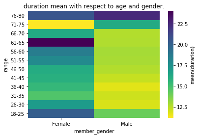

```python
cat_means=df.query('age<80')
cat_means['range'] = pd.cut(cat_means.age, [18, 25, 30, 35, 40, 45, 50, 55, 60, 65, 70, 75, 80], include_lowest=True,
                           labels = ['18-25', '26-30', '31-35', '36-40', '41-45', '46-50', '51-55', '56-60', '61-65', '66-70',
                                    '71-75', '76-80'])


cat_means = cat_means.groupby(['range', 'member_gender']).mean()['duration_min']
cat_means = cat_means.reset_index(name = 'duration_mean')


cat_means = cat_means.pivot(index = 'range', columns = 'member_gender',
                            values = 'duration_mean')



ax = sb.heatmap(cat_means, annot = False, cbar_kws = {'label' : 'mean(durarion)'}, cmap = 'viridis_r')
ax.invert_yaxis();
plt.title('duration mean with respect to age and gender.');
```

**Comment** We can see that on everage women ride bikes longer than men. The longest average time is about 25 minutes and belonges to women at 61-65 year old.

### Talk about some of the relationships you observed in this part of the investigation. Were there features that strengthened each other in terms of looking at your feature(s) of interest?

> In this section we obeserved two multivariant relationships. We noted that on weekends ride duration is higher compare to weekdays while the number of rides on weekends is much lower as we see from the facetgrid from the bevariant part of the project. We also observe mean duration as a function of age and gender.

### Were there any interesting or surprising interactions between features?

> As it was mentioned above on weekends the duration of rides are higher compare to weekdays while the number of rides is lower.